# January 6th ‘Capitol’ Twitter Data Analysis

Sage Fuentes

2026-05-05

# January 6th Twitter Data Analysis

## Goal

The goal of this analysis will be providing top down statistics and visualizations of sentiment for data from Twitter (now called X) relating to the events that took place on January 6th, 2021. The work here is exemplary and meant to show a wide, but not comprehensive, range of techniques and abilities within social media text analysis. The data was from an original analysis done in 2021, but as techniques have advanced considerably with the advent of better machine learning models and LLMs, a new analysis is being conducted.

## Data

The original data set was collected in 2021 and contains all instances of the word ‘Capitol’ from the time period of January 5th, 2021 at 12:00 AM PST to January 7th, 2021 at 11:59 PM PST. This data set was collected between August 18th and 19th 2021 using the `snscrape` Python repo which is no longer functioning for collection of Twitter/X data. Academic researcher development permissions were obtained from Twitter.

The resulting data from this cleaning and analysis will be provided in the repo.

The original data includes the following:

- Date: Datetime collected as UTC but shifted to EST for the main analysis. This is addressed in the below data cleaning.
- Username: Twitter usernames were originally collected, but have been converted to anonymized subject IDs in the resulting data. Some individual tweets from prominent users may still be included directly within discussions.
- Text: The original text of the tweet. This includes artifacts such as HTML entity encoding.
- Outlinks: Any outbound links found in the original tweet.
- ReplyCount: Number of replies to that tweet.
- RetweetCount: Number of retweets of that tweet.
- LikeCount: Number of likes on that tweet.
- QuoteCount: Number of times tweet was quoted.
- ProcessedText: This was an original attempt to process the raw text to remove elements such as HTML entity encoding. However, some forms of processing were not conducted, so text has been cleaned again detailed below.
- TextBlobSubjectivity: TextBlob Subjectivity was included in the original analysis of this data, while some older methods are included in the below work, TextBlob has been omitted from the original data.
- VADER Sentiments: Positive, negative, neutral, and a compound score for VADER were included in the original analysis. VADER analysis was performed again as the method still offers great insights for a lightweight model, however that data has been re-ran via Python as opposed to the original version due to the processing needs of the text.

### Data Cleaning

Outputs from data cleaning will not be rendered in this document to conserve space, but comprehensive comments and the full code have been preserved for transparency.

```r
# Get a list of all CSV file paths in the data folder
files <- list.files(path = "./data/raw",
                    pattern = "*.csv",
                    full.names = TRUE)

# Read them all into one data frame
# bind them together into one tibble
combined_data <- read_csv(files, id = "file_path")
# taking a glimpse to make sure that all the data types are what they need to be
# glimpse(combined_data)
```

As previously mentioned, the time range for the original collected data was from the time period of January 5th, 2021 at 12:00 AM UTC to January 7th, 2021 at 11:59 PM UTC. As the events occured in the EST or `America/New_York` timezone they are shifted here for future clarity and times after this point are all in EST.

Lastly, the data is filtered between January 5th, 2021 at 12:00 PM and January 7th, 2021 at 12:00 PM. This choice was specifically to capture the 24 hours before and after Trump’s 12 pm speech at the Eclipse in Washington D.C., the run up to the event and simultaneous events in other states, the entire period of January 6th across the entire United States as the event was being reacted to in the Los Angeles timezone well into the night and next day, and to capture the time of certification of Joe Biden as 46th President of the United State which occurred at 3:42 AM on January 7th.

```r
date_clean_data <- combined_data |>
  # Convert to EST, and rename to EST for clarity
  mutate(
    EST = Date |>
      lubridate::with_tz(tzone = "America/New_York")
  ) |>
  # Filter between noon EST on the 5th and noon EST on the 7th
  filter(
    between(
      EST,
      ymd_hms("2021-01-05 12:00:00", tz = "America/New_York"),
      ymd_hms("2021-01-07 12:00:00", tz = "America/New_York")
    )
  )
```

To preserve anonymity of users, usernames have been converted to subject ids and the original `Username` column removed. Again, some individual tweets from prominent users may still be included directly within discussions.

```r
username_clean_data <- date_clean_data |>
  # Group by Username to isolate unique individuals
  group_by(Username) |>

  # Assign a stable, matching ID, then ungroup
  mutate(subject_id = paste0("subject_", cur_group_id())) |>
  ungroup() |>

  # Remove the original Username column for strict anonymity
  select(-Username)
```

The text from the dataset next must be cleaned. Here there will be a creation of two vectors of text for different analysis purpose:

- Lexicon-friendly token-isolated vector (`token_text`): Optimized for dictionary lookup lexicons (AFINN, NRC). Text was stripped of URLs, mentions, emojis, and non-alphanumeric punctuation, then normalized to lowercase to ensure perfect string-matching against the sentiment keys.
- Syntactic context vector (`sentence_text`): Tailored for Transformer-based architectures (RoBERTa) and rule-based semantic engines (VADER). While noise like URLs and user handles were filtered out, the lexical casing, sentence structures, and punctuation syntax were intentionally preserved to capture structural modifiers, emphasis, and linguistic nuance.

Column names from old variables like `Outlinks` and `ReplyCount` have been renamed here from BigCamelCase to snake_case, in keeping with current style guide practices from tidyverse.

```r
clean_subset_data <- username_clean_data |>
  # Want to keep just the relevant information
  select(subject_id,
         Text,
         EST,
         # renaming from original BigCamelCase
         outlinks = Outlinks,
         reply_count = ReplyCount,
         retweet_count = RetweetCount,
         like_count = LikeCount,
         quote_count = QuoteCount) |>
  # want to remove duplicate tweets that are from the same user and time
  distinct(subject_id, Text, EST, .keep_all = TRUE) |>
  # Last step, cleaning the text again and making a column of hashtags for individual analysis
  mutate(
    # Extract hashtags into a list column
    hashtags = stringr::str_extract_all(Text, "#\\w+"),
    # Create a 'clean' version for word-level analysis
    sentence_text = Text |>
      textclean::replace_html(symbol = TRUE) |> # remove HTML Encoding Entities
      textclean::replace_url() |> # Remove URLs
      textclean::replace_tag() |> # Remove Mentions
      stringr::str_squish(), # Standardize spaces

    token_text = sentence_text |>
      stringr::str_replace_all("[^[:alnum:][:space:]]", " ") |> # remove
      # non-alphanumerics
      stringr::str_squish() |>  # Standardize spaces
      stringr::str_to_lower()) |>
  select(-Text)
```

Lastly, the data frame is being saved to a parquet file using `arrow` due to the efficiency of the parquet format in handling data of this size and due to the need to move this data to Python later in the analysis for support with the VADER and RoBERTa analysis.

The resulting data set includes the following variables

Attached media in the form of videos, pictures, or other documents is not represented in this data set.

```r
# Data saved here, read back in at setup for ease
pq_6th_path <- "./data/interim/jan6Dataset.parquet"
arrow::write_parquet(clean_subset_data, pq_6th_path)
```

## Analysis

### Descriptive Summary

Now that there is a cleaned data set, the first matter to attend to is a top down descriptive summary of the data. The below table includes rudimentary descriptives along with some data quality and sparsity metrics and one unique subject activity metric defined as follows.

- Zero-Engagement Trajectory Rate: represents the percentage of posts in the data set that received absolutely zero public interactions after being posted to Twitter, defined as tweets where

$$\text{reply_count}=\text{retweet_count}=\text{like_count}=\text{quote_count}=0$$

- Hashtag Sparsity Rate: represents the percentage of posts in the data set that did not include hashtags.
- External URL Inclusion Rate: represents the percentage of posts in the data set that included an external URL.
- Single Tweet Subject Rate: represents the percentage of users that tweeted only once within the data set.
- Top 1% Subject Tweet Share: represents the percentage of all tweets that were posted by the 1% of individuals that posted the most

```r
summary_metrics <- jan6_capitol_df |>
  summarise(
    # Core descriptives
    total_records   = n(),
    unique_subjects = n_distinct(subject_id),

    # Text Field Dynamics: Character Constraints
    min_char_length  = min(stringr::str_length(sentence_text),  na.rm = TRUE),
    max_char_length  = max(stringr::str_length(sentence_text),  na.rm = TRUE),
    mean_char_length = mean(stringr::str_length(sentence_text), na.rm = TRUE),

    # Text Field Dynamics: Token/Word Variations
    min_word_count  = min(
      stringr::str_count(sentence_text, "\\s+") + 1,
      na.rm = TRUE
    ),
    max_word_count  = max(
      stringr::str_count(sentence_text, "\\s+") + 1,
      na.rm = TRUE
    ),
    mean_word_count = mean(
      stringr::str_count(sentence_text, "\\s+") + 1,
      na.rm = TRUE
    ),

    # Peak Engagement Vectors
    max_replies  = max(reply_count,   na.rm = TRUE),
    max_retweets = max(retweet_count, na.rm = TRUE),
    max_likes    = max(like_count,    na.rm = TRUE),
    max_quotes   = max(quote_count,   na.rm = TRUE),

    # Central Tendency: Engagement
    # Mean and median engagement metrics give a more complete picture of
    # typical tweet performance alongside the peak values above. Max values
    # alone are easily skewed by viral outliers.
    mean_replies   = mean(reply_count,     na.rm = TRUE),
    median_replies = median(reply_count,   na.rm = TRUE),

    mean_retweets   = mean(retweet_count,   na.rm = TRUE),
    median_retweets = median(retweet_count, na.rm = TRUE),

    mean_likes   = mean(like_count,   na.rm = TRUE),
    median_likes = median(like_count, na.rm = TRUE),

    mean_quotes   = mean(quote_count,   na.rm = TRUE),
    median_quotes = median(quote_count, na.rm = TRUE),

    # Data Quality: Zero-Inflation and Sparsity Rates
    zero_engagement_rate  = mean(
      reply_count == 0 &
        retweet_count == 0 &
        like_count    == 0 &
        quote_count   == 0,
      na.rm = TRUE
    ) * 100,
    hashtag_sparsity_rate = mean(lengths(hashtags) == 0, na.rm = TRUE) * 100,
    outlinks_rate         = mean(
      !is.na(outlinks) & outlinks != "" & outlinks != "[]",
      na.rm = TRUE
    ) * 100
  )

# Subject-level tweet volume metrics
# Computed separately because they require a group_by aggregation step
# before summarising, which cannot be done inline above.
subject_tweet_counts <- jan6_capitol_df |>
  count(subject_id, name = "tweet_count")

subject_volume_metrics <- subject_tweet_counts |>
  summarise(
    # Most prolific individual subject in the corpus.
    max_tweets_by_subject = max(tweet_count),

    # Central tendency of per-subject tweet volume. A large gap between mean
    # and median indicates a small number of highly active users are driving
    # corpus volume — an important caveat for aggregate sentiment analysis.
    mean_tweets_per_subject   = mean(tweet_count),
    median_tweets_per_subject = median(tweet_count),

    # Share of subjects who tweeted exactly once. High values suggest the
    # corpus contains many incidental or low-engagement participants, which
    # contextualizes the mean/median gap above.
    single_tweet_subject_pct = mean(tweet_count == 1) * 100,

    # Share of total tweets produced by the top 1% of subjects
    # by volume. High values indicate the corpus is dominated by power users,
    # which should be noted when interpreting any aggregate sentiment results.
    top_1pct_tweet_share = {
      threshold <- quantile(tweet_count, 0.99)
      sum(tweet_count[tweet_count >= threshold]) / sum(tweet_count) * 100
    }
  )

# Bind subject-level metrics into the main summary row so the pivot below
# handles everything in a single pass.
summary_metrics <- bind_cols(summary_metrics, subject_volume_metrics)

# Format
formatted_data <- summary_metrics |>
  tidyr::pivot_longer(
    cols      = everything(),
    names_to  = "Metric",
    values_to = "Value"
  ) |>
  mutate(
    Group = case_when(
      Metric %in% c("total_records", "unique_subjects") ~
        "Corpus Volume",
      stringr::str_detect(Metric, "char_length") ~
        "Text Dynamics (Chars)",
      stringr::str_detect(Metric, "word_count") ~
        "Text Dynamics (Words)",
      Metric %in% c(
        "max_replies", "max_retweets", "max_likes", "max_quotes"
      ) ~
        "Peak Engagement",
      stringr::str_detect(
        Metric,
        "mean_repl|median_repl|mean_retw|median_retw|mean_like|median_like|mean_quot|median_quot"
      ) ~
        "Engagement Central Tendency",
      stringr::str_detect(
        Metric,
        "tweets_by_subject|tweets_per_subject|single_tweet_subject|top_1pct"
      ) ~
        "Subject Activity Distribution",
      TRUE ~
        "Data Quality & Sparsity Audit"
    ),
    Metric = case_when(
      Metric == "total_records"             ~ "Total Captured Tweets",
      Metric == "unique_subjects"           ~ "Unique User Identities (Anonymized)",
      Metric == "min_char_length"           ~ "Minimum Character Boundary",
      Metric == "max_char_length"           ~ "Maximum Character Boundary",
      Metric == "mean_char_length"          ~ "Average Structural Character Length",
      Metric == "min_word_count"            ~ "Minimum Document Word Count",
      Metric == "max_word_count"            ~ "Maximum Document Word Count",
      Metric == "mean_word_count"           ~ "Average Document Word Count",
      Metric == "max_replies"               ~ "Max Replies Received (Single Tweet)",
      Metric == "max_retweets"              ~ "Max Retweets Received (Single Tweet)",
      Metric == "max_likes"                 ~ "Max Likes Received (Single Tweet)",
      Metric == "max_quotes"                ~ "Max Quotes Received (Single Tweet)",
      Metric == "mean_replies"              ~ "Mean Replies per Tweet",
      Metric == "median_replies"            ~ "Median Replies per Tweet",
      Metric == "mean_retweets"             ~ "Mean Retweets per Tweet",
      Metric == "median_retweets"           ~ "Median Retweets per Tweet",
      Metric == "mean_likes"                ~ "Mean Likes per Tweet",
      Metric == "median_likes"              ~ "Median Likes per Tweet",
      Metric == "mean_quotes"               ~ "Mean Quotes per Tweet",
      Metric == "median_quotes"             ~ "Median Quotes per Tweet",
      Metric == "zero_engagement_rate"      ~ "Zero-Engagement Trajectory Rate",
      Metric == "hashtag_sparsity_rate"     ~ "Hashtag Sparsity Rate",
      Metric == "outlinks_rate"             ~ "External URL Inclusion Rate",
      Metric == "max_tweets_by_subject"     ~ "Most Tweets by a Single Subject",
      Metric == "mean_tweets_per_subject"   ~ "Average Tweets per Subject",
      Metric == "median_tweets_per_subject" ~ "Median Tweets per Subject",
      Metric == "single_tweet_subject_pct"  ~ "Single Tweet Subject Rate",
      Metric == "top_1pct_tweet_share"      ~ "Top 1% Subject Tweet Share"
    )
  )

# Save to render
executive_summary_table <- formatted_data |>
  group_by(Group) |>
  gt(rowname_col = "Metric") |>
  tab_header(
    title    = md("**January 6 Top Down Descriptive Summary**"),
    subtitle = "Comprehensive Architecture, String Metadata, and Behavioral Gaps"
  ) |>
  # Formatter 1: Raw integers for counts with no decimal component
  fmt_number(
    rows     = !stringr::str_detect(Metric, "Average|Mean|Median|Rate|Inclusion|Share"),
    columns  = Value,
    decimals = 0
  ) |>
  # Formatter 2: One decimal place for averages and central tendency metrics
  fmt_number(
    rows     = stringr::str_detect(Metric, "Average|Mean|Median"),
    columns  = Value,
    decimals = 1
  ) |>
  # Formatter 3: Percentage formatting for rate and share metrics
  fmt_number(
    rows     = stringr::str_detect(Metric, "Rate|Inclusion|Share"),
    columns  = Value,
    decimals = 1,
    pattern  = "{x}%"
  ) |>
  tab_style(
    style     = cell_text(color = "grey40", size = px(11)),
    locations = cells_title(groups = "subtitle")
  ) |>
  tab_style(
    style     = cell_text(size = px(14)),
    locations = cells_title(groups = "title")
  ) |>
  tab_options(
    row_group.font.weight             = "bold",
    row_group.background.color        = "grey95",
    table.border.top.color            = "black",
    table.border.bottom.color         = "black",
    column_labels.border.bottom.color = "black",
    data_row.padding                  = px(5)
  )
```

```r
# Peak Engagement Tweets
# For each engagement axis, grab the single tweet that hit the corpus maximum.
# with_ties = FALSE ensures one row per axis even when multiple tweets share
# the peak value.

peak_tweets <- bind_rows(
  jan6_capitol_df |>
    slice_max(reply_count, n = 1, with_ties = FALSE) |>
    mutate(engagement_axis = "Max Replies"),

  jan6_capitol_df |>
    slice_max(retweet_count, n = 1, with_ties = FALSE) |>
    mutate(engagement_axis = "Max Retweets"),

  jan6_capitol_df |>
    slice_max(like_count, n = 1, with_ties = FALSE) |>
    mutate(engagement_axis = "Max Likes"),

  jan6_capitol_df |>
    slice_max(quote_count, n = 1, with_ties = FALSE) |>
    mutate(engagement_axis = "Max Quotes")
  ) |>
  select(
    engagement_axis,
    EST,
    sentence_text,
    reply_count,
    retweet_count,
    like_count,
    quote_count
  )

# Render
peak_engagement_table <- peak_tweets |>
  gt(rowname_col = "engagement_axis") |>
  tab_header(
    title    = md("**Peak Engagement Tweets**"),
    subtitle = "The single highest-performing tweet on each engagement axis"
  ) |>
  cols_label(
    EST    = "Timestamp (EST)",
    sentence_text = "Tweet Text",
    reply_count   = "Replies",
    retweet_count = "Retweets",
    like_count    = "Likes",
    quote_count   = "Quotes"
  ) |>
  # Format timestamp: drop seconds for readability in a summary table
  fmt_datetime(
    columns = EST,
    format  = "MMM d, yyyy HH:mm",
    tz = "America/New_York"
  ) |>
  fmt_number(
    columns  = c(reply_count, retweet_count, like_count, quote_count),
    decimals = 0
  ) |>
  cols_width(
    EST    ~ px(140),
    sentence_text ~ px(360),
    everything()  ~ px(80)
  ) |>
  tab_style(
    style     = cell_text(style = "italic", color = "grey30"),
    locations = cells_body(columns = sentence_text)
  ) |>
  tab_style(
    style     = cell_text(size = px(11), color = "grey40"),
    locations = cells_body(columns = c(EST))
  ) |>
  # Bold the axis-defining cell in each row so the peak stat reads at a glance
  tab_style(
    style     = cell_text(weight = "bold"),
    locations = cells_body(
      columns = reply_count,
      rows    = engagement_axis == "Max Replies"
    )
  ) |>
  tab_style(
    style     = cell_text(weight = "bold"),
    locations = cells_body(
      columns = retweet_count,
      rows    = engagement_axis == "Max Retweets"
    )
  ) |>
  tab_style(
    style     = cell_text(weight = "bold"),
    locations = cells_body(
      columns = like_count,
      rows    = engagement_axis == "Max Likes"
    )
  ) |>
  tab_style(
    style     = cell_text(weight = "bold"),
    locations = cells_body(
      columns = quote_count,
      rows    = engagement_axis == "Max Quotes"
    )
  ) |>
  tab_style(
    style     = cell_text(color = "grey40", size = px(11)),
    locations = cells_title(groups = "subtitle")
  ) |>
  tab_style(
    style     = cell_text(size = px(14)),
    locations = cells_title(groups = "title")
  ) |>
  tab_options(
    row_group.font.weight             = "bold",
    table.border.top.color            = "black",
    table.border.bottom.color         = "black",
    column_labels.border.bottom.color = "black",
    data_row.padding                  = px(5)
  )
```

```r
executive_summary_table
```

**January 6 Top Down Descriptive Summary**

Comprehensive Architecture, String Metadata, and Behavioral Gaps

|  | Value |
| --- | --- |
| Corpus Volume |  |
| Total Captured Tweets | 1,334,399 |
| Unique User Identities (Anonymized) | 743,274 |
| Text Dynamics (Chars) |  |
| Minimum Character Boundary | 5 |
| Maximum Character Boundary | 864 |
| Average Structural Character Length | 149.3 |
| Text Dynamics (Words) |  |
| Minimum Document Word Count | 1 |
| Maximum Document Word Count | 97 |
| Average Document Word Count | 24.9 |
| Peak Engagement |  |
| Max Replies Received (Single Tweet) | 85,552 |
| Max Retweets Received (Single Tweet) | 182,530 |
| Max Likes Received (Single Tweet) | 925,035 |
| Max Quotes Received (Single Tweet) | 61,607 |
| Engagement Central Tendency |  |
| Mean Replies per Tweet | 2.9 |
| Median Replies per Tweet | 0.0 |
| Mean Retweets per Tweet | 11.9 |
| Median Retweets per Tweet | 0.0 |
| Mean Likes per Tweet | 52.3 |
| Median Likes per Tweet | 1.0 |
| Mean Quotes per Tweet | 1.6 |
| Median Quotes per Tweet | 0.0 |
| Data Quality & Sparsity Audit |  |
| Zero-Engagement Trajectory Rate | 38.8% |
| Hashtag Sparsity Rate | 86.7% |
| External URL Inclusion Rate | 24.1% |
| Subject Activity Distribution |  |
| Most Tweets by a Single Subject | 264 |
| Average Tweets per Subject | 1.8 |
| Median Tweets per Subject | 1.0 |
| Single Tweet Subject Rate | 70.5% |
| Top 1% Subject Tweet Share | 12.4% |

```r
peak_engagement_table
```

**Peak Engagement Tweets**

The single highest-performing tweet on each engagement axis

|  | Timestamp (EST) | Tweet Text | Replies | Retweets | Likes | Quotes |
| --- | --- | --- | --- | --- | --- | --- |
| Max Replies | Jan 6, 2021 14:47 | Violence is always unacceptable. Even when passions run high. Anyone engaged in violence—especially against law enforcement—should be fully prosecuted. God bless the Capitol Police and the honorable m… | 85,552 | 10,178 | 65,184 | 15,297 |
| Max Retweets | Jan 6, 2021 23:29 | Y’all mad a woman is shot dead while storming a Capitol building but don’t care when a woman is shot dead while sleeping in her own house? 🤔 | 4,288 | 182,530 | 729,918 | 5,985 |
| Max Likes | Jan 6, 2021 19:56 | Here’s my statement on today’s violence at the Capitol. | 17,057 | 170,483 | 925,035 | 9,867 |
| Max Quotes | Jan 6, 2021 13:10 | BREAKING: Trump supporters have breached the Capitol building, tearing down 4 layers of security fencing and are attempting to occupy the building — fighting federal police who are overrun This is the… | 19,586 | 42,421 | 85,710 | 61,607 |

#### Assessment of Descriptive Summary

Several key elements are prominent within this descriptive summary primarily around volume, subject activity, sparsity, and peak engagement.

The 4 tweets representing the most replies, retweets, likes, and quotes within this timeframe have been extracted for viewing. As these are all public figures, links to each tweet have been included. Notably, due to the time this data was collected and the constantly moving nature of Twitter/X, there is some variation in reported numbers for replies, retweets, likes, and quotes in the current live versions

### Tweet Volume Timeline

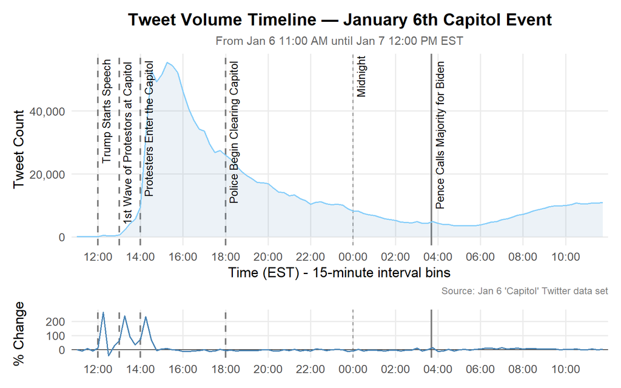

```r
tweet_volume <- jan6_capitol_df |>
  mutate(
    time_bin = lubridate::floor_date(EST, unit = "15 minutes")
  ) |>
  filter(time_bin >= ymd_hms("2021-01-06 11:00:00", tz = "America/New_York"),
         time_bin <= ymd_hms("2021-01-07 11:59:59", tz = "America/New_York")) |>
  summarise(
    tweet_count = sum(!is.na(sentence_text)),
    .by         = time_bin
  ) |>
  arrange(time_bin) |>
  mutate(
    # Percent change in tweet count relative to the previous 30-minute bin.
    # lag() looks back one bin; the +1 offset on the denominator avoids
    # division by zero in bins where the prior count was 0.
    pct_change = (tweet_count - lag(tweet_count)) /
      (lag(tweet_count) + 1) * 100,
    # As there will be an NA for the first row, change that to a zero just to
    # reduce warnings in the graph
    pct_change = tidyr::replace_na(pct_change, 0)
  )

# Event reference times for geom_text() labels only. linetype and linewidth
# are intentionally omitted here; those properties are set directly in the
# geom_vline() calls below to avoid ggplot scaling them as aesthetics,
# which inflates their rendered thickness.
events <- tibble(
  xintercept = ymd_hms(
    c(
      "2021-01-07 00:00:00",
      "2021-01-06 12:00:00",
      "2021-01-06 13:00:00",
      "2021-01-06 14:00:00",
      "2021-01-06 18:00:00",
      "2021-01-07 03:42:00"
    ),
    tz = "America/New_York"
  ),
  label = c(
    "Midnight",
    "Trump Starts Speech",
    "1st Wave of Protestors at Capitol",
    "Protesters Enter the Capitol",
    "Police Begin Clearing Capitol",
    "Pence Calls Majority for Biden"
  )
)

volume_plot <- ggplot(tweet_volume, aes(x = time_bin, y = tweet_count)) +
  # Faint midnight marker
  geom_vline(
    xintercept = ymd_hms("2021-01-07 00:00:00", tz = "America/New_York"),
    linetype   = "dashed",
    linewidth  = 0.4,
    color      = "grey50"
  ) +
  # Thick dashed event lines
  geom_vline(
    xintercept = ymd_hms(
      c(
        "2021-01-06 12:00:00",
        "2021-01-06 13:00:00",
        "2021-01-06 14:00:00",
        "2021-01-06 18:00:00"
      ),
      tz = "America/New_York"
    ),
    linetype  = "dashed",
    linewidth = 0.8,
    color     = "grey50"
  ) +
  # Solid line for Pence
  geom_vline(
    xintercept = ymd_hms("2021-01-07 03:42:00", tz = "America/New_York"),
    linetype   = "solid",
    linewidth  = 0.8,
    color      = "grey50"
  ) +
  geom_area(fill = "steelblue", alpha = 0.10) +
  geom_line(linewidth = 0.7, color = "lightskyblue") +

  geom_text(
    data        = events,
    aes(x = xintercept, label = label),
    y           = Inf,
    vjust       = 1.4,
    hjust       = 1.05,
    angle       = 90,
    size        = 3.5,
    color       = "black",
    inherit.aes = FALSE
  ) +
  scale_x_datetime(
    date_breaks = "2 hours",
    date_labels = "%H:%M",
    timezone    = "America/New_York",
    expand      = expansion(mult = c(0.01, 0.01))
  ) +
  scale_y_continuous(labels = scales::comma) +
  labs(
    title    = "Tweet Volume Timeline — January 6th Capitol Event",
    subtitle = "From Jan 6 11:00 AM until Jan 7 12:00 PM EST",
    x        = "Time (EST) - 15-minute interval bins",
    y        = "Tweet Count",
    caption  = "Source: Jan 6 'Capitol' Twitter data set"
  ) +
  theme_minimal(base_size = 13) +
  theme(
    plot.title       = element_text(face = "bold", hjust = 0.5),
    plot.subtitle    = element_text(color = "grey40", size = 11, hjust = 0.5),
    plot.caption     = element_text(color = "grey50", size = 9),
    panel.grid.minor = element_blank()
  )

roc_plot <- ggplot(tweet_volume, aes(x = time_bin, y = pct_change)) +
  # Event reference lines — same as volume plot for visual alignment
  geom_vline(
    xintercept = ymd_hms("2021-01-07 00:00:00", tz = "America/New_York"),
    linetype   = "dashed",
    linewidth  = 0.4,
    color      = "grey50"
  ) +
  geom_vline(
    xintercept = ymd_hms(
      c(
        "2021-01-06 12:00:00",
        "2021-01-06 13:00:00",
        "2021-01-06 14:00:00",
        "2021-01-06 18:00:00"
      ),
      tz = "America/New_York"
    ),
    linetype  = "dashed",
    linewidth = 0.8,
    color     = "grey50"
  ) +
  geom_vline(
    xintercept = ymd_hms("2021-01-07 03:42:00", tz = "America/New_York"),
    linetype   = "solid",
    linewidth  = 0.8,
    color      = "grey50"
  ) +
  geom_hline(yintercept = 0, linewidth = 0.4, color = "grey30") +
  geom_line(linewidth = 0.6, color = "steelblue") +
  scale_x_datetime(
    date_breaks = "2 hours",
    date_labels = "%H:%M",
    timezone    = "America/New_York",
    expand      = expansion(mult = c(0.01, 0.01))
  ) +
  scale_y_continuous(labels = scales::comma) +
  labs(
    x = NULL,
    y = "% Change"
  ) +
  theme_minimal(base_size = 13) +
  theme(
    plot.subtitle    = element_text(color = "grey40", size = 11, hjust = 0.5),
    panel.grid.minor = element_blank()
  )

patchwork::wrap_plots(
  volume_plot,
  roc_plot,
  ncol    = 1,
  heights = c(4, 1)
)
```

For tweet volume timeline, times were binned to a 15-minute interval after experimentation with 10- and 30- minute intervals. 30-minute intervals offered little insight into smaller changes within the data while 10-minute intervals were much the same as 15-minute interval visualizations without distinct peaks in change.

Times before January 6th 11:00 AM were removed due to limited activity in comparison to the scope of this data (hundreds of tweets as opposed to thousands of them).

#### Assessment of Tweet Volume Timeline

As seen in the graph above, notable events within the timeline of January 6 do seem to manifest directly into changes in Twitter activity. This is most notable in the sharp increase of tweets after protesters entered the Capitol at 2:00 PM. The rate of change and 15-minute interval binning manage to accentuate the near instantaneous nature of social media and Twitter with peaks in posts culminating only minutes after events were unfolding within Washington D.C. While some degree of persistent chatter continued throughout the next day and into the next, there were no major changes in rate of change even as the Capitol began to be cleared and as Pence called the electoral college majority for Joe Biden.

### Token-level Sentiment Analysis

Diving into sentiment analysis, this analysis will first start with token-level approaches. While many of these are surpassed by more modern methods, they can still offer important insights from a corpus of data. First steps will be creating the tokenized version of the data set, omitting stop words, and generating a list of top 15 words in the data set, not including the term ‘Capitol’ due to the presence of the term in each tweet.

```r
# Tokenize
tokenized_words <- jan6_capitol_df |>
  collect() |>
  # Tokenization
  tidytext::unnest_tokens(word, token_text, drop = FALSE) |>
  # Remove stop words
  anti_join(stop_words, by = "word")

# Saving to conserve time
arrow::write_parquet(tokenized_words, "./data/interim/tokenized_words.parquet")
```

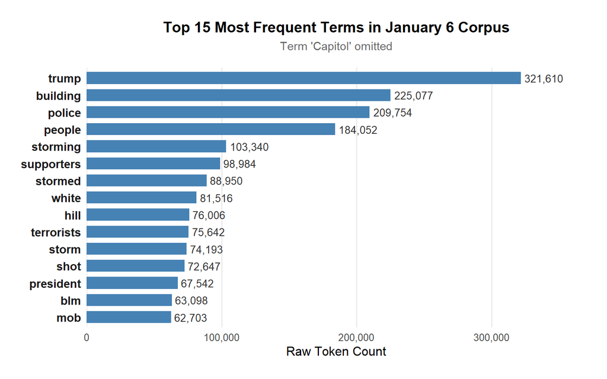

```r
tweet_word_freq <- tokenized_words |>
  count(word, sort = TRUE) |>
  slice(2:16)

tweet_word_freq |>
  ggplot(aes(x = n, y = reorder(word, n))) +

  # Structural elements: Using a standard corporate palette for accessibility
  geom_col(fill = "steelblue", width = 0.7) +

  # Inline value annotation to eliminate axis-tracking cognitive load
  geom_text(
    aes(label = scales::comma(n)),
    hjust = -0.1,
    size = 3.5,
    color = "grey20"
  ) +

  # Aesthetic bounding: Prevents right-hand coordinate clipping on value strings
  scale_x_continuous(
    labels = scales::comma,
    expand = expansion(mult = c(0, 0.15))
  ) +

  # Semantic framework and contextual labeling
  labs(
    title = "Top 15 Most Frequent Terms in January 6 Corpus",
    subtitle = "Term 'Capitol' omitted",
    x = "Raw Token Count",
    y = NULL
  ) +

  # Minimal typographic layer mapping
  theme_minimal(base_size = 12) +
  theme(
    plot.title = element_text(face = "bold",
                              size = 14,
                              color = "black",
                              hjust = 0.5),
    plot.subtitle = element_text(size = 11,
                                 color = "grey40",
                                 margin = margin(b = 15),
                                 hjust = 0.5),
    panel.grid.major.y = element_blank(), # Suppress redundant horizontal coordinates
    panel.grid.minor = element_blank(),
    axis.text.y = element_text(face = "bold", color = "grey10", size = 11),
    plot.margin = margin(20, 20, 20, 20)
  )
```

#### Custom Stop Words

While traditional stop words are already removed from the `tokenized_words` data frame, some custom stop words may be necessary for certain analysis methods, potentially highlighting a shortcoming or obstacle with that method.

```r
# anti_join with tokenized_words in instances with
custom_stop_words <- tibble(
  word = c("capitol","trump", "don", "united"
           ),
  lexicon = "custom"
)
```

#### AFINN Sentiment

The first sentiment analysis used will be the AFINN sentiment analysis lexicon. This lexicon assigns individual words within its lexicon scores ranging from -5 to +5. AFINN relies on the valence of words to give scoring. Sentence level scores can be calculated using sums of all the words in the analyzed sentence, a normalized score averaging words across a sentence, or normalized scores averaging across a tweet. As some tweets are much longer than others, a normalized score is useful here for comparisons.

There is no official documentation on how neutrality is handled within normalized, composite AFINN scores, so for the purposes of this analysis Neutral composite scores have been defined here as normalized scores within the range (-0.05, 0.05), similar to how they are handled within VADER.

```r
# Enforce a consistent factor order for sentiment labels so every plot
# uses the same left-to-right sequence: negative → neutral → positive.
sentiment_levels <- c("negative", "neutral", "positive")
sentiment_colours <- c(
  "negative" = "firebrick3",
  "neutral"  = "darkgrey",
  "positive" = "seagreen4"
)

# AFINN Sentiment Score per Word
afinn_sentiment_words <- tokenized_words |>
  select(EST, token_text, word) |>
  # removing custom stop words
  anti_join(custom_stop_words, by = "word") |>
  # Acquire sentiments
  left_join(tidytext::get_sentiments("afinn"), by = "word")

# Join with sentiments and categorize
afinn_word_sentiment_cat <- afinn_sentiment_words |>
  # Filter out words that didn't have an AFINN match
  filter(!is.na(value)) |>
  mutate(category = ifelse(value > 0, "Positive", "Negative"))

# Get Top 10 words per category
afinn_top_words_by_cat <- afinn_word_sentiment_cat |>
  summarise(n = n(),
            .by = c(category,
                    word)
            ) |>
  slice_max(n, n = 10, with_ties = FALSE, by = category)

# Comparison Bar Chart
afinn_token_bar_chart <- ggplot(afinn_top_words_by_cat,
       aes(x = reorder_within(word, n, category),
           y = n,
           fill = category)) +
  geom_col(show.legend = FALSE, alpha = 0.8) +

  # Wanted this annotated
  geom_text(aes(label = format(n, big.mark = ",")),
            hjust = -0.1,
            size = 3.5,
            fontface = "bold",
            color = "gray20") +

  # Allow labels to be drawn outside the panel (CRITICAL)
  coord_flip(clip = "off") +

  # facet_wrap set to free due to scale
  facet_wrap(~category, scales = "free") +
  scale_x_reordered() +

  # Named Colors
  scale_fill_manual(values = c("Positive" = "seagreen4", "Negative" = "firebrick3")) +

  # Increase expansion to 30% to accommodate large numbers/outliers
  scale_y_continuous(expand = expansion(mult = c(0, 0.3))) +

  theme_minimal(base_size = 12) +
  theme(
    plot.title = element_text(hjust = 0.5, face = "bold", size = 16),
    plot.subtitle = element_text(hjust = 0.5, size = 11, color = "gray30"),
    panel.grid.major.y = element_blank(),
    strip.text = element_text(face = "bold", size = 12),
    # Increase the right margin of the entire plot as a safety net
    plot.margin = margin(10, 50, 10, 10)
  ) +
  labs(
    title = "Top 10 Most Prevalent Sentiment-Bearing Words",
    subtitle = "Lexical prevalence within the AFINN sentiment dictionary",
    x = NULL,
    y = "Total Frequency of Occurrences"
  )

# AFINN Sentiment Analysis
# Average AFINN score per tweet, then bin into sentiment categories using a
# ±0.05 neutral band. Exact zero is rare when averaging across tokens, so a
# small buffer prevents artificially inflating the neutral category.
afinn_sentiment_summary <- afinn_sentiment_words |>
  filter(!is.na(value)) |>
  summarise(
    afinn_sentiment_score = mean(value, na.rm = TRUE),
    .by = c(EST, token_text)
  ) |>
  mutate(
    afinn_label = case_when(
      afinn_sentiment_score >  0.05 ~ "positive",
      afinn_sentiment_score < -0.05 ~ "negative",
      .default                      = "neutral"
    ) |>
      factor(levels = sentiment_levels)
  )

# Aggregate counts and percentage labels for each sentiment class
afinn_bar_data <- afinn_sentiment_summary |>
  count(afinn_label) |>
  mutate(pct = n / sum(n))

# --- Bar Chart: Sentiment Label Distribution ---
afinn_bar <- ggplot(
  afinn_bar_data, aes(x = afinn_label, y = n, fill = afinn_label)
) +
  geom_col(width = 0.6, show.legend = FALSE) +
  geom_text(
    aes(label = paste0(comma(n), "\n(", percent(pct, accuracy = 0.1), ")")),
    vjust  = -0.4,
    size   = 3.5,
    colour = "grey30"
  ) +
  scale_fill_manual(values = sentiment_colours) +
  scale_y_continuous(
    labels = comma,
    expand = expansion(mult = c(0, 0.18))
  ) +
  labs(
    title    = "AFINN Sentiment Label Counts",
    subtitle = "January 6th 'Capitol' Twitter Dataset — averaged per tweet",
    x        = paste0("Sentiment Label\nn = ", comma(sum(afinn_bar_data$n))),
    y        = "Tweet Count"
  ) +
  theme_minimal(base_size = 12) +
  theme(
    plot.title         = element_text(face = "bold", hjust = 0.5),
    plot.subtitle      = element_text(colour = "grey40", hjust = 0.5),
    panel.grid.major.x = element_blank()
  )

# Density Plot: Distribution of Continuous Scores
# Mean reference line is mapped through aes() so it appears in the legend
afinn_mean <- mean(afinn_sentiment_summary$afinn_sentiment_score)

afinn_density <- ggplot(
  afinn_sentiment_summary, aes(x = afinn_sentiment_score)
) +
  geom_density(fill = "lightgoldenrod", colour = "darkblue", alpha = 0.6) +
  geom_vline(
    aes(xintercept = afinn_mean, linetype = "Mean", colour = "Mean"),
    linewidth = 0.8
  ) +
  # Shade the neutral band so the ±0.05 threshold is visually anchored
  annotate(
    "rect",
    xmin = -0.05, xmax = 0.05,
    ymin = -Inf,  ymax = Inf,
    fill = "grey80", alpha = 0.4
  ) +
  scale_colour_manual(
    name   = "Summary Statistic",
    values = c("Mean" = "red")
  ) +
  scale_linetype_manual(
    name   = "Summary Statistic",
    values = c("Mean" = "dashed")
  ) +
  labs(
    title    = "Density of AFINN Normalized Sentiment Scores",
    subtitle = "Shaded band indicates ±0.05 neutral threshold",
    x        = paste0(
      "Mean Token Score per Tweet\nn = ",
      comma(nrow(afinn_sentiment_summary))
    ),
    y = "Density"
  ) +
  theme_minimal(base_size = 12) +
  theme(
    plot.title           = element_text(face = "bold", hjust = 0.5),
    plot.subtitle        = element_text(colour = "grey40", hjust = 0.5),
    legend.position      = c(0.88, 0.88),
    legend.justification = c("right", "top"),
    legend.background    = element_rect(
      fill      = "white",
      colour    = "grey80",
      linewidth = 0.3
    ),
    legend.margin = margin(4, 6, 4, 6),
    legend.title  = element_text(face = "bold")
  )
```

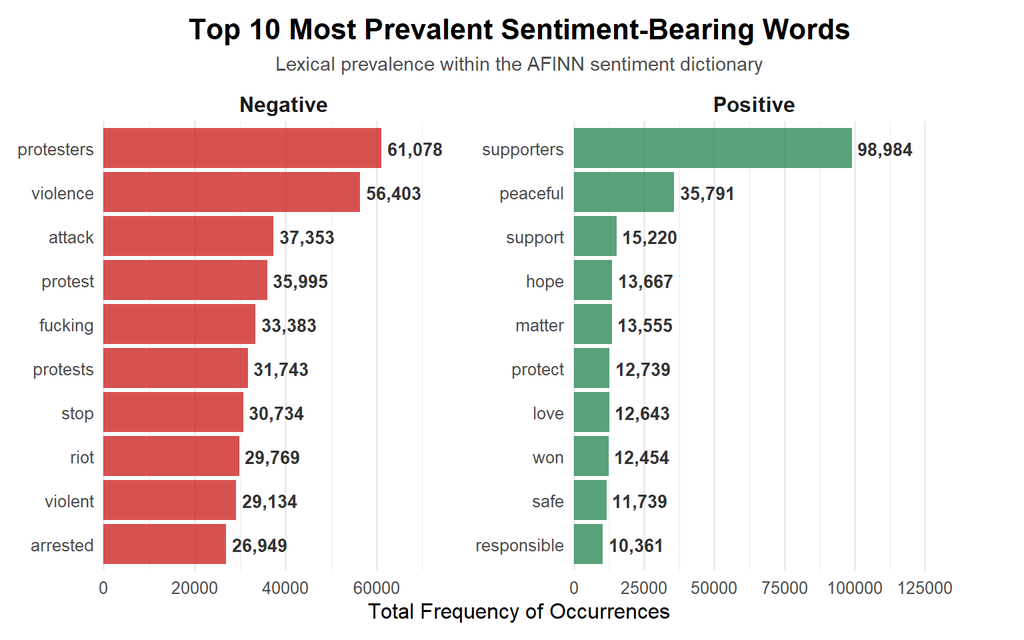

```r
afinn_token_bar_chart
```

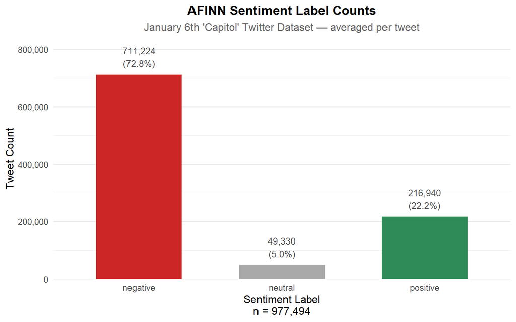

```r
afinn_bar
```

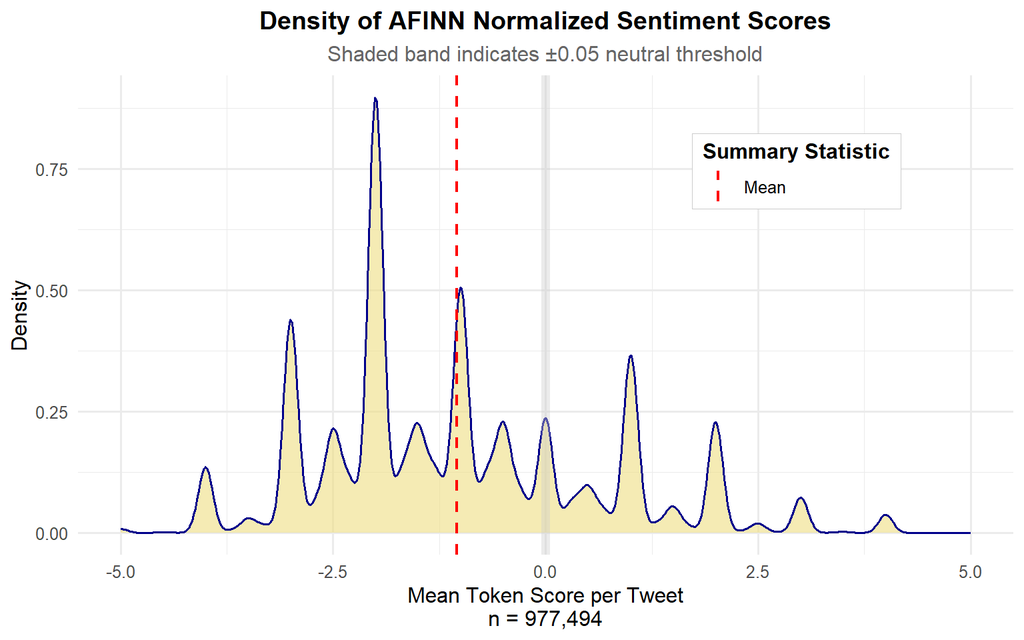

```r
afinn_density
```

##### Assessment of AFINN

The results of AFINN already provide some telling information regarding our top-most tokens and the overall landscape of sentiment within the data set. First, some tweets were fully omitted as they did not contain any of the words from the AFINN lexicon. We can’t simply mark these as neutral as they still may contain negative or positive sentiment that is just a byproduct of differing language. The top tokens in both the negative and positive categories are terms referring to participants in the actions on January 6th, ‘protesters’ as a negative term and ‘supporters’ as a positive term. This does not enlighten the nature of the overall tweets with these terms, but gives guiding posts in how to consider the data qualitatively. Looking at examples from the data set, outside of more neutral considerations such as recounting events, the use of protester and supporter seemed to be used to also make comparisons to other groups, accusations to other groups, and condemning the use of supporter or protester in favor of terms like terrorist or insurrectionist.

Examples taken from top 200 liked or quoted tweets:

- Holy shit. Matt Gaetz just said, “some of the people who breached the Capitol today were not Trump supporters, they were masquerading as Trump supporters and in fact were members of the violent terrorist group antifa.”
- “There is no doubt in my mind that if those were Black Lives Matter protesters yesterday breaking into the Capitol Building, there would be dozens and dozens of people dead today,” Former CIA Acting and Deputy Director @MichaelJMorell tells @vladduthiersCBS
- “That’s not a protest, that’s a terrorist attack. … Stop using the same word, it’s disrespectful. It’s ridiculous, and it’s shameful to keep calling them protesters.” Draymond Green speaks on the pro-Trump mob breaching the Capitol (via @KNBR)

This also points out another limitation of AFINN, due to the lack of context that comes with a lexicon approach, it doesn’t provide any real understanding for negations or modifiers on the overall nature of the usage of the word. The density plot and bar chart paint a much more comprehensive view with the overall sentiment being negative by majority. As this portion will be useful to compare to the VADER and RoBERTa later on, due to their improvements in syntactic context, any changes in sentiment directionality should be noted.

Pulling directly from data,‘Rioter’ is not a word contained within the AFINN lexicon, but it did appeared in 39,039 tweets. Additionally, while not included enough in the top tokens, the term ‘insurrectionist’ appeared in 10,933 tweets.

#### VADER

VADER (Valence Aware Dictionary and sEntiment Reasoner) is a rule-based sentiment analysis tool developed by Hutto & Gilbert (2014) and designed specifically for social media text. Unlike purely lexicon-driven approaches such as AFINN, VADER incorporates a set of grammatical and syntactical heuristics that allow it to account for features common in informal digital communication such as capitalization for emphasis, punctuation intensity (e.g., repeated exclamation marks), degree modifiers such as “very” or “kind of”, and negation handling. Each tweet is scored on a continuous compound scale ranging from -1 (maximally negative) to +1 (maximally positive), with the conventional thresholds of ≤ -0.05 for negative, ≥ 0.05 for positive, and the band in between classified as neutral. Analysis was performed in Python using the `vaderSentiment` library on the syntactically preserved `sentence_text` field, with results written back to parquet for integration here. VADER was not conducted in R due to the library being recently removed from CRAN, and while it was possible to install and run an archived version, it was substantially slower in R (estimated 3 hours in R versus less than a few minutes in Python).

```r
vader_data <- vader_data |>
  mutate(vader_label = factor(vader_label, levels = sentiment_levels))

# Compute counts and percentage labels for each sentiment class.
vader_pct_data <- vader_data |>
  count(vader_label) |>
  mutate(
    pct       = n / sum(n),
    pct_label = paste0(vader_label, "\n", percent(pct, accuracy = 0.1))
  )

vader_bar_chart <- ggplot(vader_pct_data,
                          aes(x = vader_label, y = n, fill = vader_label)) +
  geom_col(width = 0.6, show.legend = FALSE) +
  geom_text(
    aes(label = paste0(comma(n), "\n(", percent(pct, accuracy = 0.1), ")")),
    vjust    = -0.4,
    size     = 3.5,
    colour   = "grey30"
  ) +
  scale_fill_manual(values = sentiment_colours) +
  scale_y_continuous(
    labels = comma,
    # Increased upper multiplier to 0.18 so count labels above the tallest
    # bar are never clipped by the plot boundary.
    expand = expansion(mult = c(0, 0.18))
  ) +
  labs(
    title    = "VADER Sentiment Label Counts",
    subtitle = "January 6th 'Capitol' Twitter Dataset",
    x        = paste0("Sentiment Label\nn = ", comma(sum(vader_pct_data$n))),
    y        = "Tweet Count"
  ) +
  theme_minimal(base_size = 12) +
  theme(
    plot.title    = element_text(face = "bold", hjust = 0.5),
    plot.subtitle = element_text(colour = "grey40", hjust = 0.5),
    panel.grid.major.x = element_blank()
  )

# VADER Density plot
vader_compound_mean   <- mean(vader_data$vader_compound)

vader_density <- ggplot(vader_data, aes(x = vader_compound)) +
  geom_density(fill = "lightgoldenrod", colour = "darkblue", alpha = 0.6) +
  geom_vline(
    aes(xintercept = vader_compound_mean,
        linetype = "Mean",
        colour = "Mean"),
    linewidth = 0.8
  ) +
  # Shade the neutral band so the ±0.05 threshold is visually anchored
  annotate(
    "rect",
    xmin = -0.05, xmax = 0.05,
    ymin = -Inf,  ymax = Inf,
    fill = "grey80", alpha = 0.4
  ) +
  scale_colour_manual(
    name   = "Summary Statistic",
    values = c("Mean" = "red")
  ) +
  scale_linetype_manual(
    name   = "Summary Statistic",
    values = c("Mean" = "dashed")
  ) +
  scale_x_continuous(limits = c(-1, 1), breaks = seq(-1, 1, 0.25)) +
  labs(
    title    = "Density of VADER Compound Scores",
    subtitle = "Shaded band indicates ±0.05 neutral threshold",
    x        = paste0("Compound Score\nn = ", comma(nrow(vader_data))),
    y        = "Density"
  ) +
  theme_minimal(base_size = 12) +
  theme(
    plot.title    = element_text(face = "bold", hjust = 0.5),
    plot.subtitle = element_text(colour = "grey40", hjust = 0.5),
    legend.position      = c(0.88, 0.88),
    legend.justification = c("right", "top"),
    legend.background    = element_rect(fill = "white", colour = "grey80", linewidth = 0.3),
    legend.margin        = margin(4, 6, 4, 6),
    legend.title         = element_text(face = "bold")
  )
```

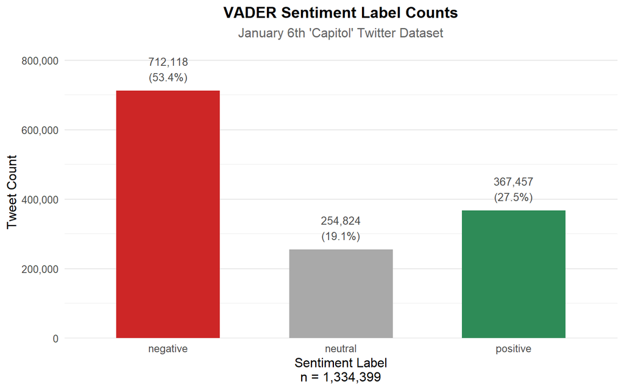

```r
vader_bar_chart
```

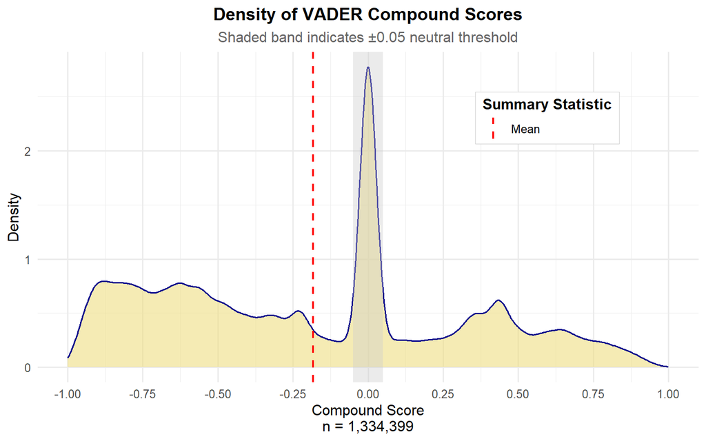

```r
vader_density
```

##### Assessment of VADER

VADER’s results offer a meaningfully different picture from AFINN, with a higher proportion of neutral tweets and a modest reduction in negative classification. This is expected as VADER was designed specifically for social media text and accounts for capitalization, punctuation intensity, degree modifiers, and negation, all features that appear frequently in politically charged Twitter discourse. Where AFINN omits any tweet containing no matched lexicon terms, VADER scores the full sentence without coverage gaps, which reduces the selection bias toward more expressive language that affected the AFINN sample. The compound score density reflects this as the distribution is smoother and more continuous, with clear negative skew while the neutral band captures the volume of factual reporting and retweet-driven content that AFINN could not score.

#### RoBERTa

RoBERTa (Robustly Optimized BERT Pretraining Approach) is a transformer- based model fine-tuned on the `cardiffnlp/twitter-roberta-base-sentiment` checkpoint, which was specifically trained on Twitter data. Unlike lexicon- based approaches, RoBERTa evaluates the full sentence context of each tweet rather than scoring individual tokens in isolation, making it substantially more sensitive to negation, sarcasm, and syntactic modifiers. Inference was performed in Python via the Hugging Face `transformers` library and results were written back to parquet for integration here.

```r
roberta_data <- roberta_data |>
  mutate(roberta_label = factor(roberta_label, levels = sentiment_levels))

roberta_graph_data <- roberta_data |>
  count(roberta_label) |>
  mutate(
    pct       = n / sum(n),
    pct_label = paste0(roberta_label, "\n", percent(pct, accuracy = 0.1))
  )

roberta_bar <- ggplot(roberta_graph_data,
                      aes(x = roberta_label, y = n, fill = roberta_label)) +
  geom_col(width = 0.6, show.legend = FALSE) +
  geom_text(
    aes(label = paste0(comma(n), "\n(", percent(pct, accuracy = 0.1), ")")),
    vjust  = -0.4,
    size   = 3.5,
    colour = "grey30"
  ) +
  scale_fill_manual(values = sentiment_colours) +
  scale_y_continuous(
    labels = comma,
    expand = expansion(mult = c(0, 0.18))
  ) +
  labs(
    title    = "RoBERTa Sentiment Label Counts",
    subtitle = "January 6th 'Capitol' Twitter Dataset",
    x        = paste0("Sentiment Label\nn = ", comma(sum(roberta_graph_data$n))),
    y        = "Tweet Count"
  ) +
  theme_minimal(base_size = 12) +
  theme(
    plot.title         = element_text(face = "bold", hjust = 0.5),
    plot.subtitle      = element_text(colour = "grey40", hjust = 0.5),
    panel.grid.major.x = element_blank()
  )

# --- Sentiment Volume Over Time ---
# RoBERTa inference was performed in Python on the full January 6th corpus
# and written back to parquet, preserving all original fields including EST.
# This allows direct binning without a join — roberta_data is a complete
# record of the original dataset with sentiment labels appended.
roberta_sentiment_volume <- roberta_data |>
  mutate(
    time_bin = lubridate::floor_date(EST, unit = "15 minutes")
  ) |>
  # Mirror the filter cutoff used in the main volume chart for comparability
  filter(time_bin >= ymd_hms("2021-01-06 11:00:00", tz = "America/New_York"),
         time_bin <= ymd_hms("2021-01-07 11:59:59", tz = "America/New_York")) |>
  summarise(
    tweet_count = n(),
    .by         = c(time_bin, roberta_label)
  ) |>
  arrange(time_bin) |>
  # Factor ordering controls stacking sequence and legend order
  mutate(roberta_label = factor(roberta_label, levels = sentiment_levels))

# Stacked Area Chart: Sentiment Class Volume Over Time
# Stacked rather than overlapping so total height remains comparable to the
# main volume chart, while the fill decomposition shows how sentiment class
# composition shifts across key event windows.
roberta_timeline <- ggplot(roberta_sentiment_volume,
       aes(x = time_bin, y = tweet_count, fill = roberta_label)) +
  # Event reference lines drawn before data layers so they sit behind the fill
  geom_vline(
    xintercept = ymd_hms("2021-01-07 00:00:00", tz = "America/New_York"),
    linetype   = "dashed",
    linewidth  = 0.4,
    color      = "grey50"
  ) +
  geom_vline(
    xintercept = ymd_hms(
      c(
        "2021-01-06 12:00:00",
        "2021-01-06 13:00:00",
        "2021-01-06 14:00:00",
        "2021-01-06 18:00:00"
      ),
      tz = "America/New_York"
    ),
    linetype  = "dashed",
    linewidth = 0.8,
    color     = "grey50"
  ) +
  geom_vline(
    xintercept = ymd_hms("2021-01-07 03:42:00", tz = "America/New_York"),
    linetype   = "solid",
    linewidth  = 0.8,
    color      = "grey50"
  ) +
  geom_area(alpha = 0.8, position = "stack") +
  scale_fill_manual(
    name   = "Sentiment",
    values = sentiment_colours
  ) +
  # Event labels pinned to top of panel
  geom_text(
    data        = events,
    aes(x = xintercept, label = label),
    y           = Inf,
    vjust       = 1.4,
    hjust       = 1.05,
    angle       = 90,
    size        = 3,
    color       = "black",
    inherit.aes = FALSE
  ) +
  scale_x_datetime(
    date_breaks = "2 hours",
    date_labels = "%H:%M",
    timezone    = "America/New_York",
    expand      = expansion(mult = c(0.01, 0.01))
  ) +
  scale_y_continuous(labels = scales::comma) +
  labs(
    title    = "Tweet Sentiment Volume Over Time — January 6th Capitol Event",
    subtitle = "15-minute interval bins by RoBERTa sentiment class, Eastern Time",
    x        = "Time (EST)",
    y        = "Tweet Count",
    caption  = "Source: Jan 6 'Capitol' Twitter data"
  ) +
  theme_minimal(base_size = 13) +
  theme(
    plot.title      = element_text(face = "bold", hjust = 0.5),
    plot.subtitle   = element_text(color = "grey40", size = 11, hjust = 0.5),
    plot.caption    = element_text(color = "grey50", size = 9),
    panel.grid.minor = element_blank(),
    # Bottom legend keeps the top panel clear for the event line labels
    legend.position = "bottom"
  )
```

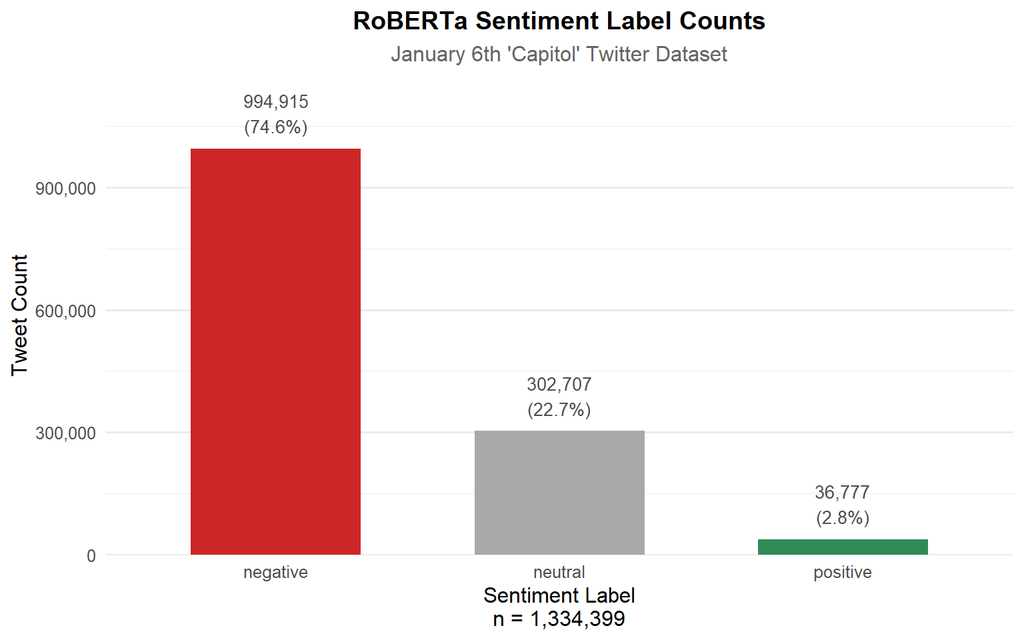

```r
roberta_bar
```

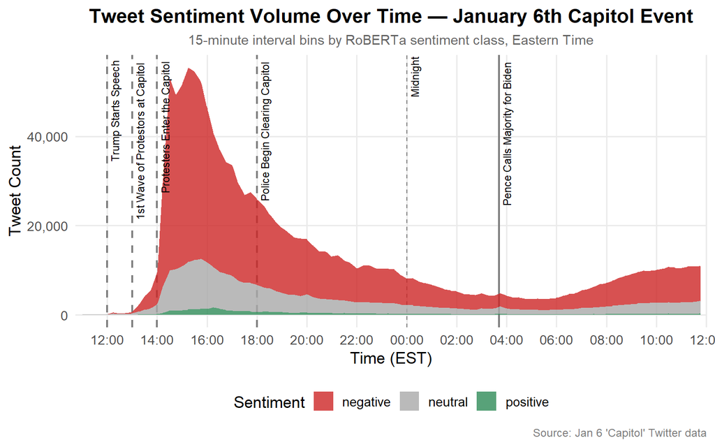

```r
roberta_timeline
```

RoBERTa’s label distribution reinforces the consensus established by AFINN and VADER, negative sentiment was the dominant force across the January 6th corpus. However, the proportions differ in ways that reflect the model’s architectural advantages. As a transformer fine-tuned on approximately 124 million tweets, RoBERTa evaluates full sentence context rather than isolated tokens, making it substantially more sensitive to negation, sarcasm, and syntactic modifiers that lexicon-based methods systematically misclassify. The sentiment timeline makes the most compelling case for this contextual sensitivity, negative sentiment was not merely dominant in aggregate but remained the dominant class throughout the entire event window.

A persistent limitation across all three methods is that the positionality and directionality of negativity, who negativity is directed at and from what ideological position, cannot be inferred without additional modeling. Topic modeling (LDA) or Named Entity Recognition (NER) would be natural extensions and may be addressed in a follow-up analysis.

## Appendix A: NRC Emotions

While originally visualized, NRC analysis was not included in the main analysis due to difference in design and output not being comparable to more robust methods. Inclusion here has been provided for viewing.

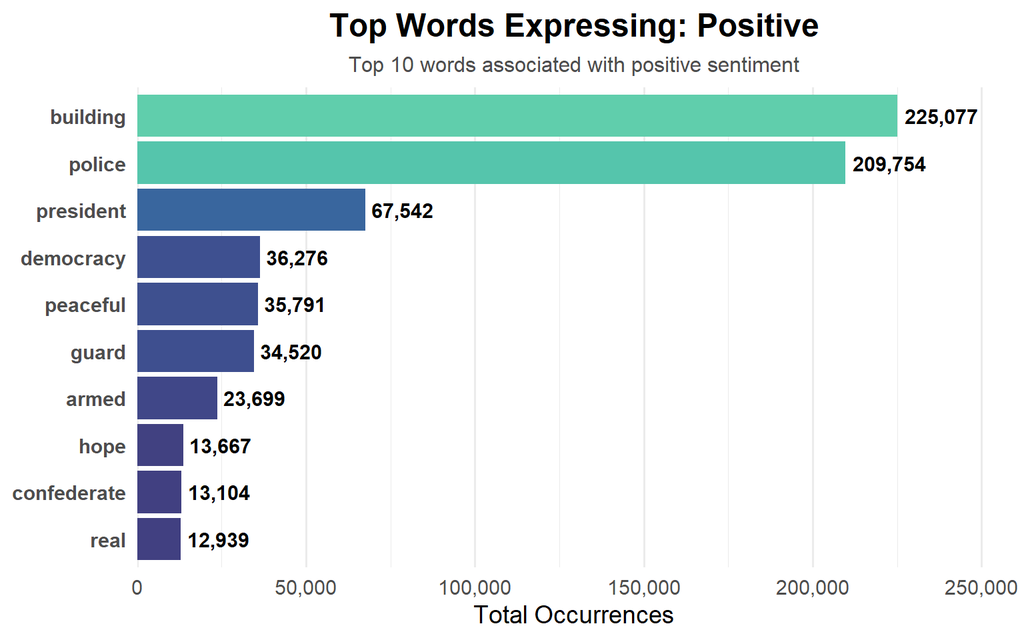

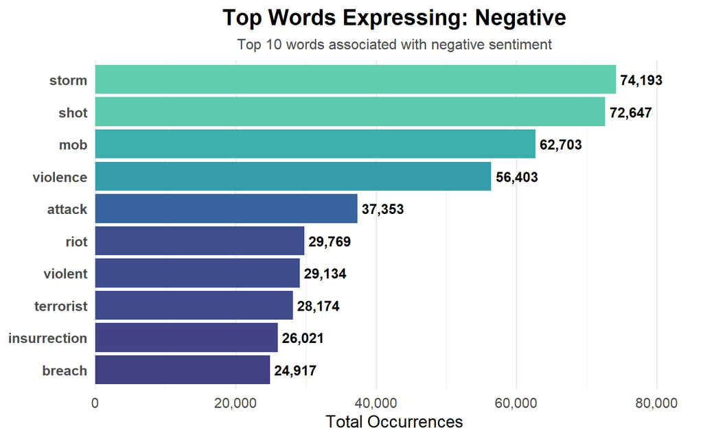

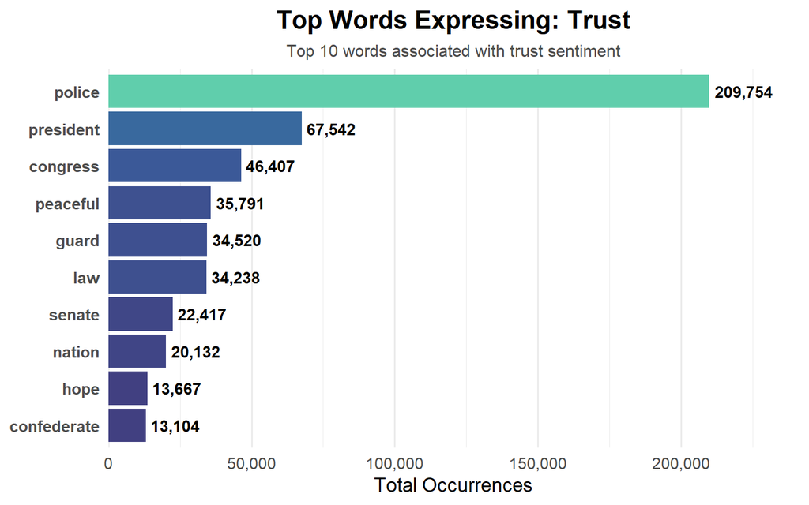

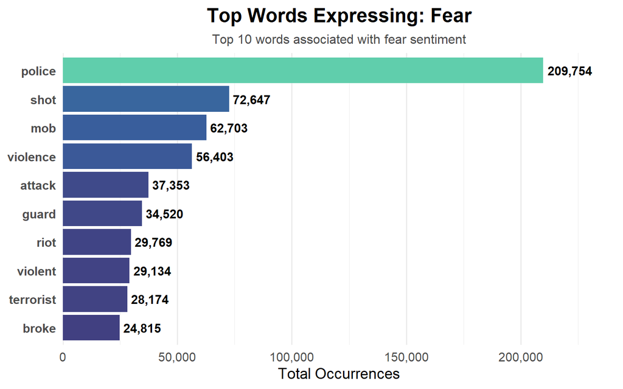

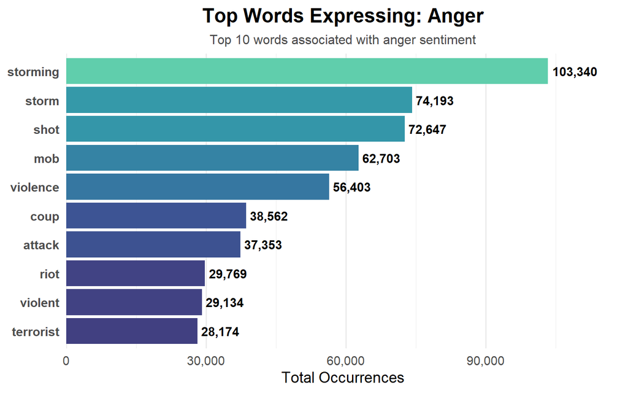

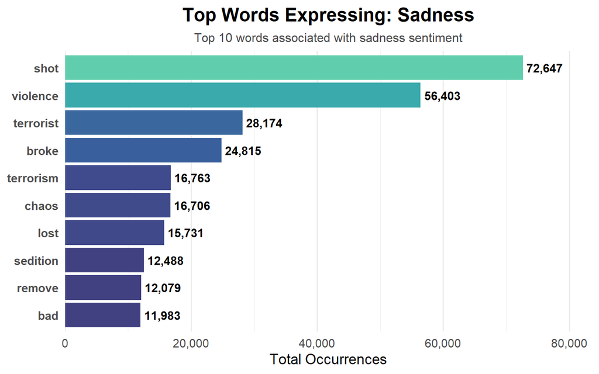

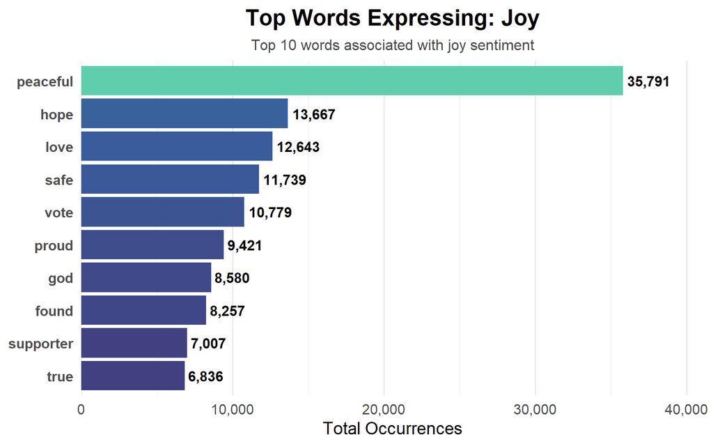

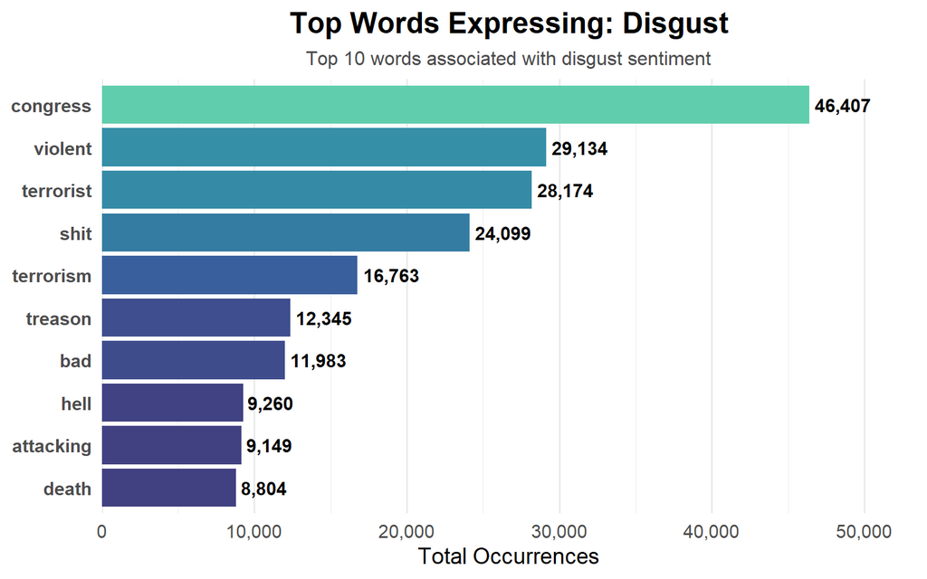

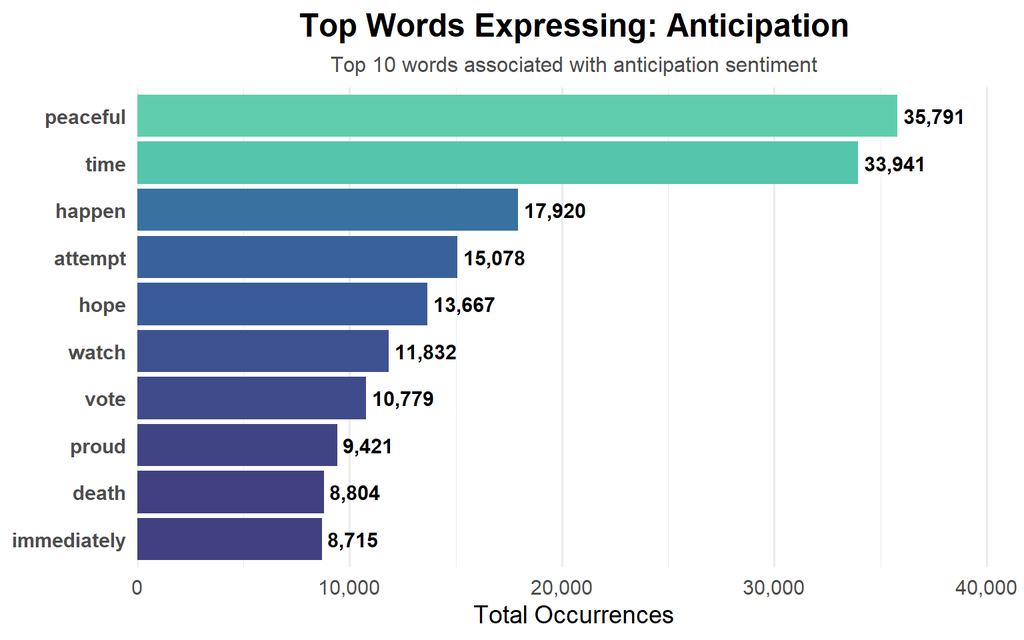

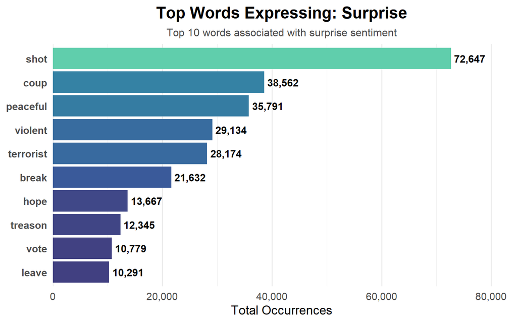

```r
nrc_emotions <- tokenized_words |>
  # removing custom stop words
  anti_join(custom_stop_words, by = "word") |>
  # Joining NRC sentiments
  inner_join(tidytext::get_sentiments("nrc"),
             by = "word",
             relationship = "many-to-many") |>
  count(word, sentiment, sort = TRUE)

# Visualizing emotion distribution
# Get the list of unique emotions
emotion_list <- unique(nrc_emotions$sentiment)

# Manually ordered for logical reading sequence: valence first, then emotions
emotion_order <- c(
  "positive", "negative",
  "trust", "fear", "anger",
  "sadness", "joy", "disgust",
  "anticipation", "surprise"
)

# Loop through and print each plot
for (emo in emotion_order) {

  # Filter data for the specific emotion
  plot_nrc_emotions <- nrc_emotions |>
    filter(sentiment == emo) |>
    # Limit to top 10
    slice_max(n, n = 10)

  # Create the plot
  p <- ggplot(plot_nrc_emotions, aes(x = n, y = reorder(word, n))) +
    # Draw the bars
    geom_col(aes(fill = n), show.legend = FALSE) +
    geom_text(aes(label = scales::comma(n)),
              hjust = -0.1,          # Moves text slightly to the right of the bar
              size = 4,              # Adjust text size
              fontface = "bold") +
    # Added a subtle gradient fill
    scale_fill_viridis_c(option = "mako", begin = 0.3, end = 0.8) +
    # Expand x-axis so the labels don't get cut off
    scale_x_continuous(expand = expansion(mult = c(0, .15)), labels = comma) +
    theme_minimal(base_size = 14) +
    labs(
      title = paste("Top Words Expressing:", stringr::str_to_title(emo)),
      subtitle = paste("Top 10 words associated with", emo, "sentiment"),
      x = "Total Occurrences",
      y = NULL
    ) +
    theme(
      # Centering the title and subtitle
      plot.title = element_text(face = "bold", hjust = 0.5, size = 18),
      plot.subtitle = element_text(hjust = 0.5, size = 12, color = "gray30"),
      panel.grid.major.y = element_blank(),
      axis.text.y = element_text(face = "bold")
    )

  # In Rmd loops, you must explicitly print the plot
  print(p)
}
```

## References

BBC News. (2023, August 2). *Capitol riots timeline: What happened on 6 January 2021?* BBC. https://www.bbc.com/news/world-us-canada-56004916

Hutto, C. J., & Gilbert, E. (2014). VADER: A parsimonious rule-based model for sentiment analysis of social media text. *Proceedings of the Eighth International AAAI Conference on Weblogs and Social Media (ICWSM-14).* https://ojs.aaai.org/index.php/ICWSM/article/view/14550

JustAnotherArchivist. (n.d.). *snscrape: A social networking service scraper in Python* [Software]. GitHub. https://github.com/JustAnotherArchivist/snscrape

Lonsdorf, K. (2022, January 5). *A timeline of how the Jan. 6 attack unfolded, including who said what and when.* NPR. https://www.npr.org/2022/01/05/1069977469/a-timeline-of-how-the-jan-6-attack-unfolded-including-who-said-what-and-when

Liu, Y., Ott, M., Goyal, N., Du, J., Joshi, M., Chen, D., Levy, O., Lewis, M., Zettlemoyer, L., & Stoyanov, V. (2019). *RoBERTa: A robustly optimized BERT pretraining approach.* arXiv. https://arxiv.org/abs/1907.11692

Nielsen, F. Å. (2011). A new ANEW: Evaluation of a word list for sentiment analysis in microblogs. In M. Rowe, M. Stankovic, A.-S. Dadzie, & M. Hardey (Eds.), *Proceedings of the ESWC2011 Workshop on Making Sense of Microposts* (Vol. 718, pp. 93–98). http://ceur-ws.org/Vol-718/paper_16.pdf

Mohammad, S. M., & Turney, P. D. (2013). Crowdsourcing a word-emotion association lexicon. *Computational Intelligence, 29*(3), 436–465. https://doi.org/10.1111/j.1467-8640.2012.00460.x

Warriner, A. B., Kuperman, V., & Brysbaert, M. (2013). Norms of valence, arousal, and dominance for 13,915 English lemmas. *Behavior Research Methods, 45,* 1191–1207. https://doi.org/10.3758/s13428-013-0403-5